# Presentation

Vanessa Ortiz & Claudia Lopez

2024-04-21

# Introduction

The data set used was sourced from DataQuest which provided us with data collected from Covid 19 cases, documented from the first 6 months of 2020 from over 100 countries. We also used data from Kaggle to collect the population of each country in 2020.

[This is the link to DataQuest.](https://www.dataquest.io/)

[This is the link to Kaggle.](https://www.kaggle.com/datasets/tanuprabhu/population-by-country-2020)

# Questions

- What are the top 10 countries with the most covid-19 cases?
- What are the top 5 countries with the least covid-19 cases?
- What is the relationship between hospitalization and deaths from covid-19?
- Is there any correlation between the country population and covid-19 cases?
- When was the peak of the most cases for covid?

# Packages Used

- library(tidyverse)
- library(ggplot2)
- library(lubridate) #this package was used to separate the dates into separate columns
- library(scales) #this package was used to label the axis with percent

# Unfiltered Data

```
## Rows: 10,903
## Columns: 14
## $ Date                    <chr> "2020-01-20", "2020-01-22", "2020-01-22", "202…
## $ Continent_Name          <chr> "Asia", "North America", "North America", "Nor…
## $ Two_Letter_Country_Code <chr> "KR", "US", "US", "US", "US", "KR", "US", "US"…
## $ Country_Region          <chr> "South Korea", "United States", "United States…
## $ Province_State          <chr> "All States", "All States", "Washington", "All…
## $ positive                <int> 1, 1, 1, 1, 1, 2, 1, 1, 4, 0, 3, 0, 0, 0, 0, 1…
## $ hospitalized            <int> 0, 0, 0, 0, 0, 0, 0, 0, 0, 0, 0, 0, 0, 0, 0, 0…
## $ recovered               <int> 0, 0, 0, 0, 0, 0, 0, 0, 0, 0, 0, 0, 0, 0, 0, 0…
## $ death                   <int> 0, 0, 0, 0, 0, 0, 0, 0, 0, 0, 0, 0, 0, 0, 0, 0…
## $ total_tested            <int> 4, 1, 1, 1, 1, 27, 1, 1, 0, 0, 0, 0, 0, 0, 0, …
## $ active                  <int> 0, 0, 0, 0, 0, 0, 0, 0, 0, 0, 0, 0, 0, 0, 0, 0…
## $ hospitalizedCurr        <int> 0, 0, 0, 0, 0, 0, 0, 0, 0, 0, 0, 0, 0, 0, 0, 0…
## $ daily_tested            <int> 0, 0, 0, 0, 0, 5, 0, 0, 0, 0, 0, 0, 0, 0, 0, 0…
## $ daily_positive          <int> 0, 0, 0, 0, 0, 0, 0, 0, 0, 0, 0, 0, 0, 0, 0, 0…
```

# Data Key Terms

- **Country**: Country of origin
- **Continent**: Continent where data was documented
- **Population**: NNumber of people in said country
- **Month**: Month the data was collected
- **Day**:Day the dat was collected
- **Positive**: Postive covid-19 cases recorded
- **Hospitalization**: recorded number of poeple in a hospital due to covid
- **Deaths**:Number of people who passed due to covid-19

# Filtering the Data

```
## Rows: 3,779
## Columns: 8
## $ date             <date> 2020-01-20, 2020-01-22, 2020-01-23, 2020-01-24, 2020…
## $ month            <dbl> 1, 1, 1, 1, 1, 1, 1, 1, 1, 1, 1, 1, 1, 1, 1, 1, 1, 1,…
## $ day              <dbl> 20, 22, 23, 24, 24, 25, 25, 25, 26, 26, 26, 26, 26, 2…
## $ Continent_Name   <chr> "Asia", "North America", "North America", "Asia", "No…
## $ Country_Region   <chr> "South Korea", "United States", "United States", "Sou…
## $ positive         <int> 1, 1, 1, 2, 1, 4, 1, 1, 4, 0, 3, 1, 1, 5, 0, 0, 4, 2,…
## $ death            <int> 0, 0, 0, 0, 0, 0, 0, 0, 0, 0, 0, 0, 0, 0, 0, 0, 0, 0,…
## $ hospitalizedCurr <int> 0, 0, 0, 0, 0, 0, 0, 0, 0, 0, 0, 0, 0, 0, 0, 0, 0, 0,…
```

# Top 10 countries with Most Cases

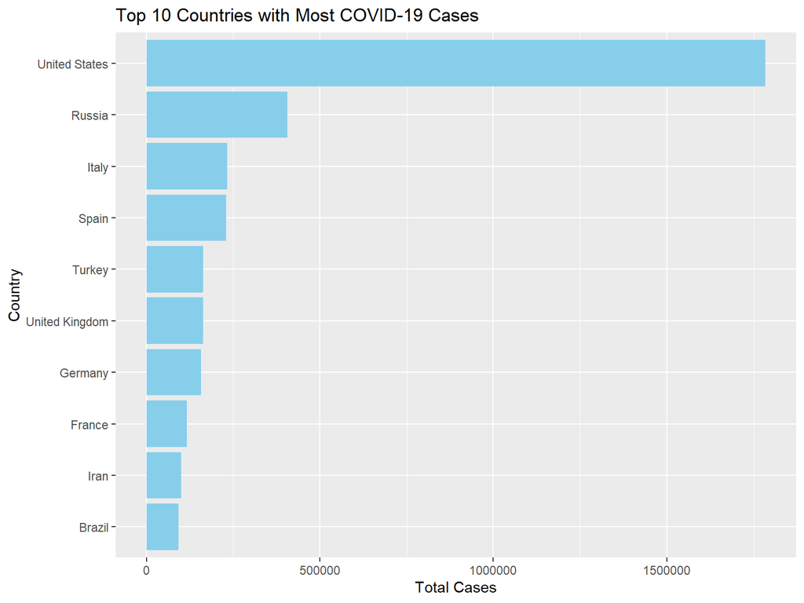

# Top 10 countries with Most Cases on Average

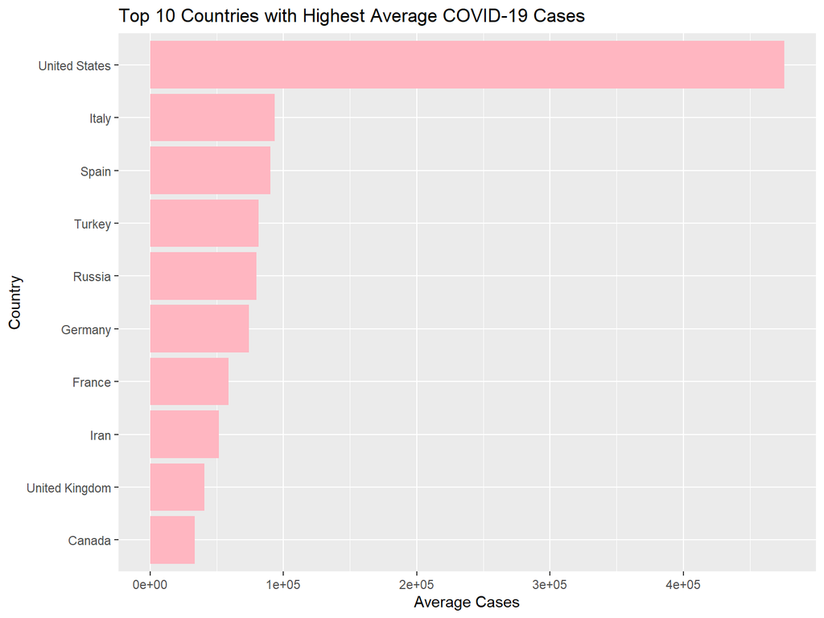

# Top 5 Countries with Least Cases

```
## # A tibble: 5 × 2
##   Country_Region   max
##   <chr>          <int>
## 1 Ethiopia           0
## 2 Mauritius          0
## 3 North Korea        0
## 4 Grenada           18
## 5 Malawi            41
```

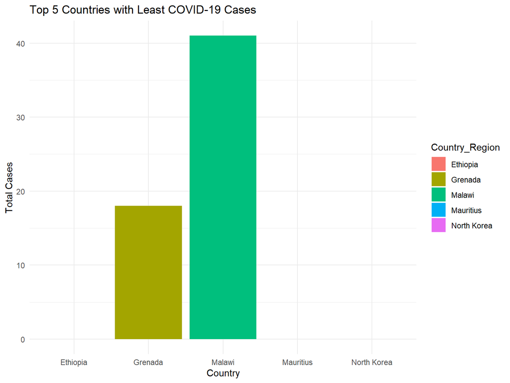

# Top 10 Countries with Least Cases on Average

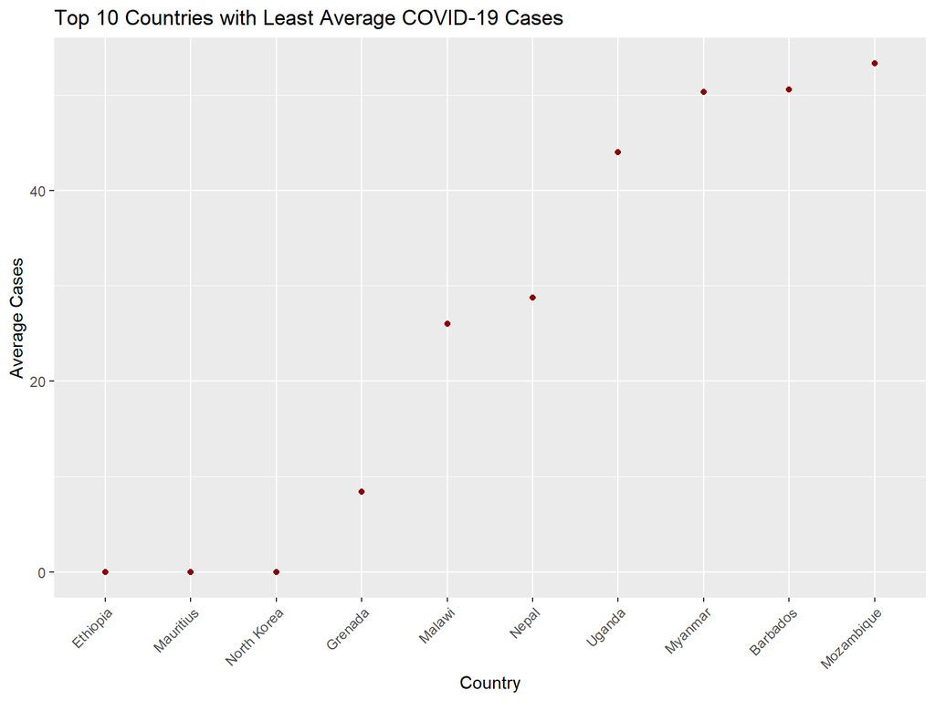

# Relationship Between Hospitalized Cases and Deaths

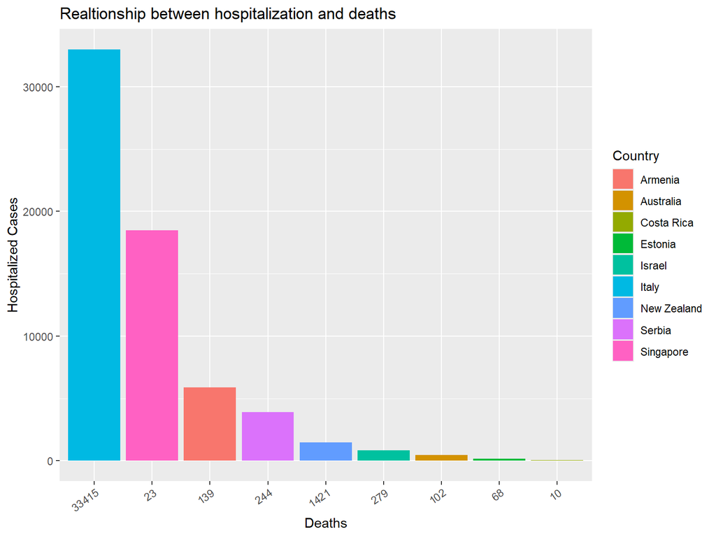

# Relationship Between Hospitalized Cases and Deaths

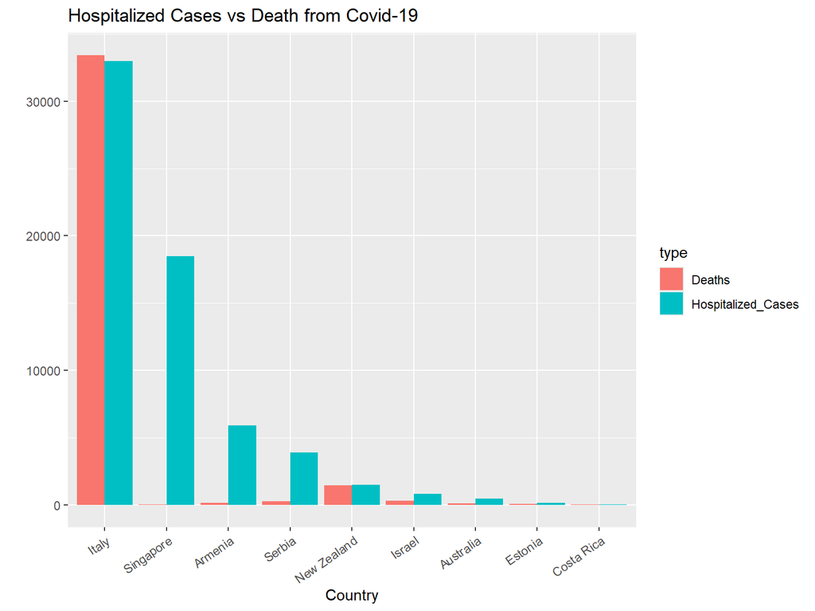

# Correlation between Population and Covid-19 Cases

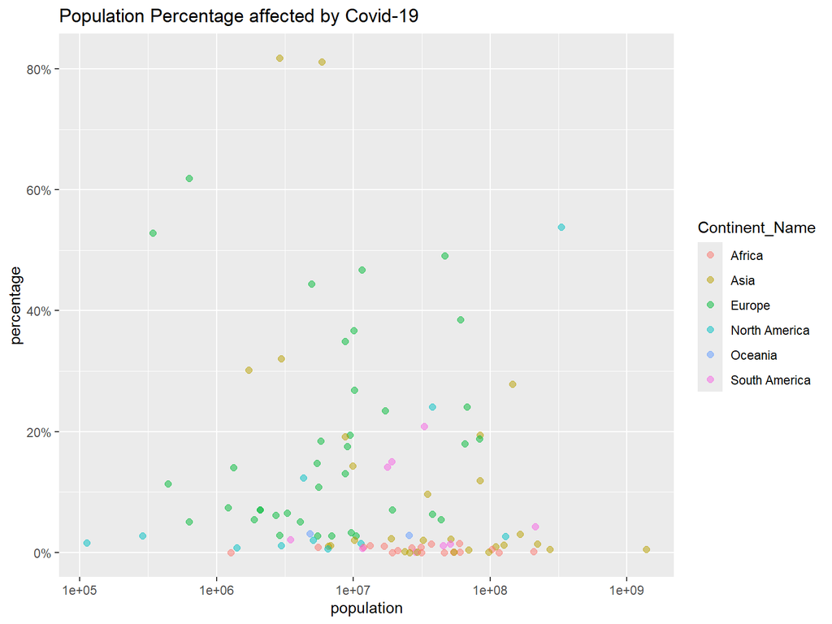

# Correlation between Population and Covid-19 Cases

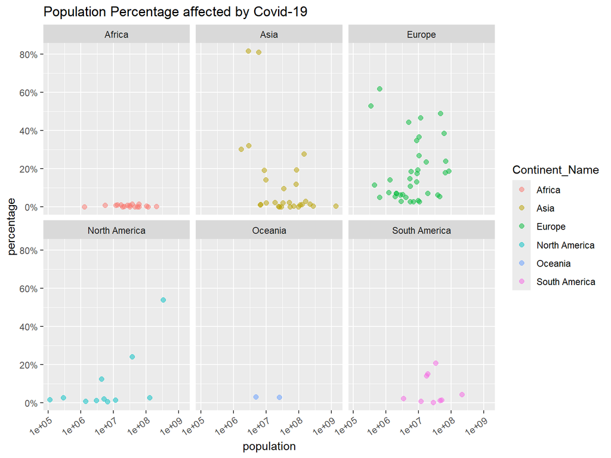

# Correlation between Population and Covid-19 Cases

### Africa

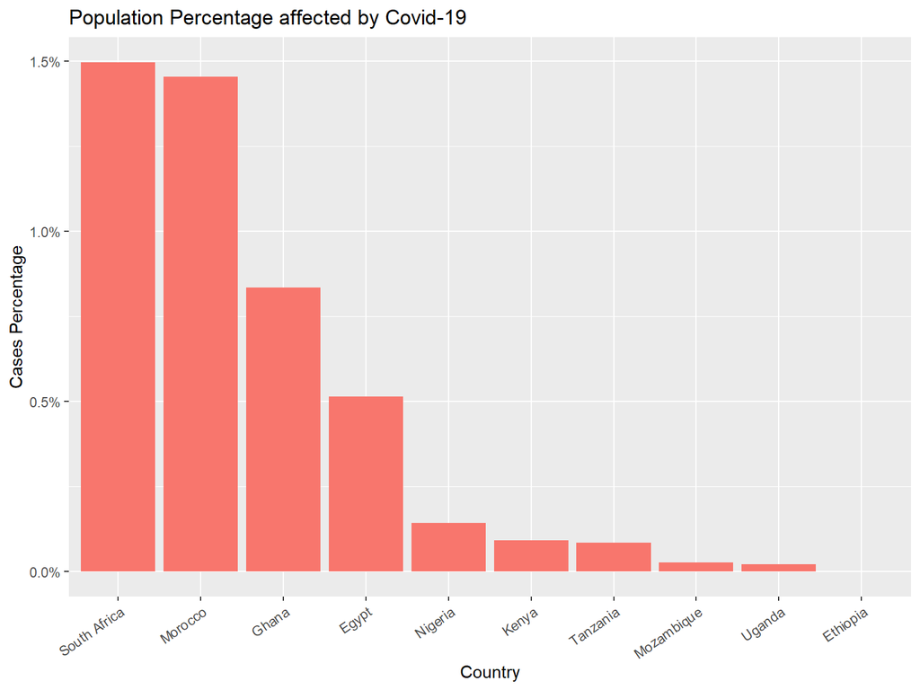

# Correlation between Population and Covid-19 Cases

### Asia

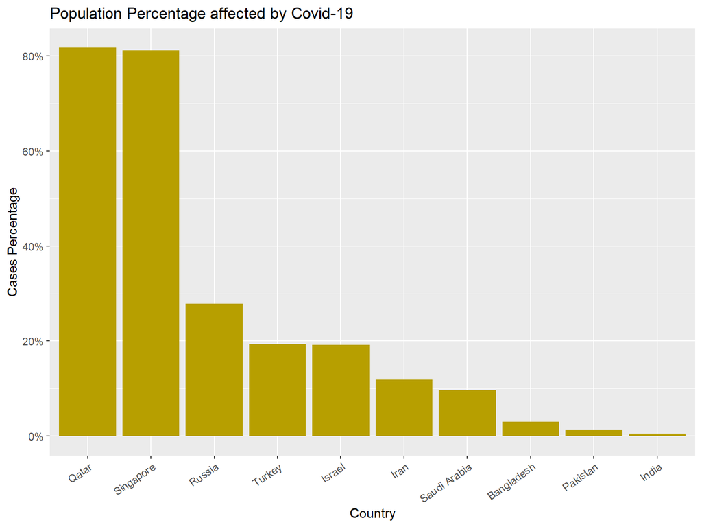

# Correlation between Population and Covid-19 Cases

### Europe

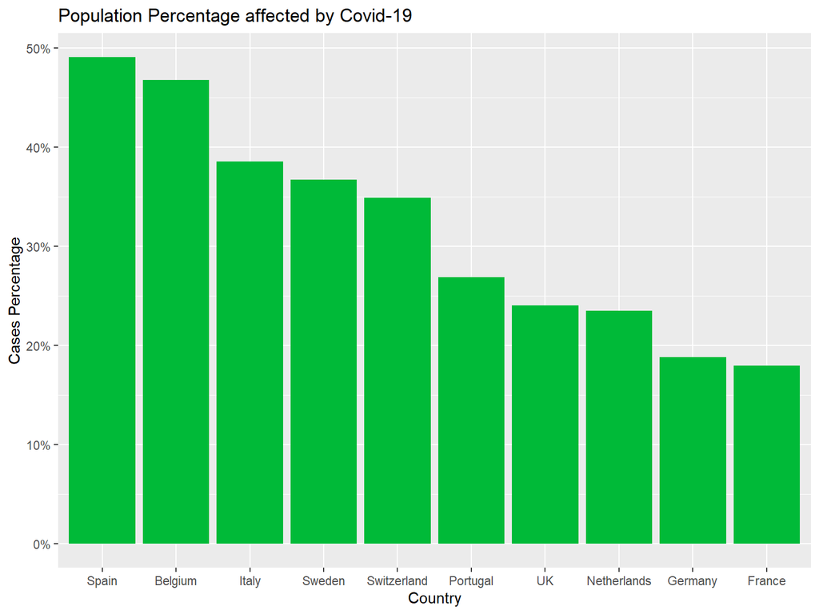

# Correlation between Population and Covid-19 Cases

### North America

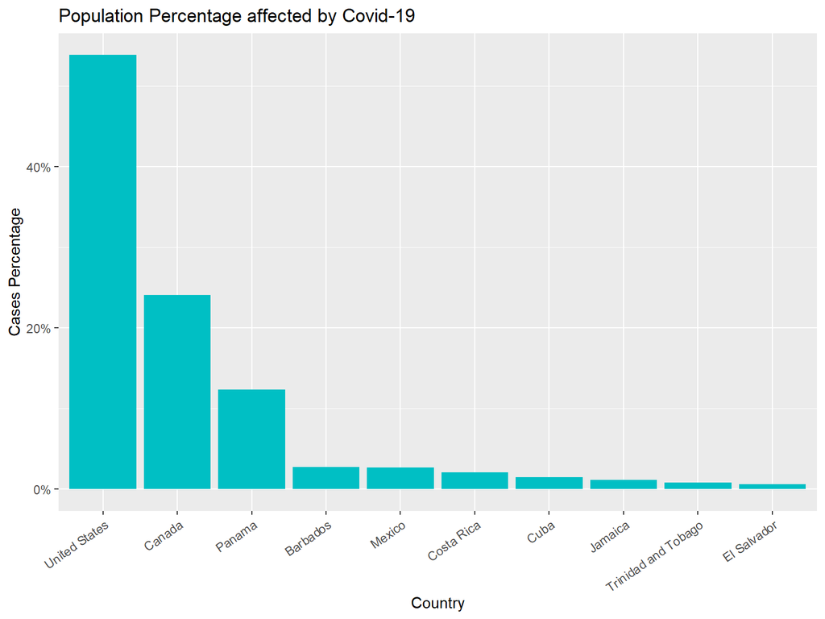

# Correlation between Population and Covid-19 Cases

### South America

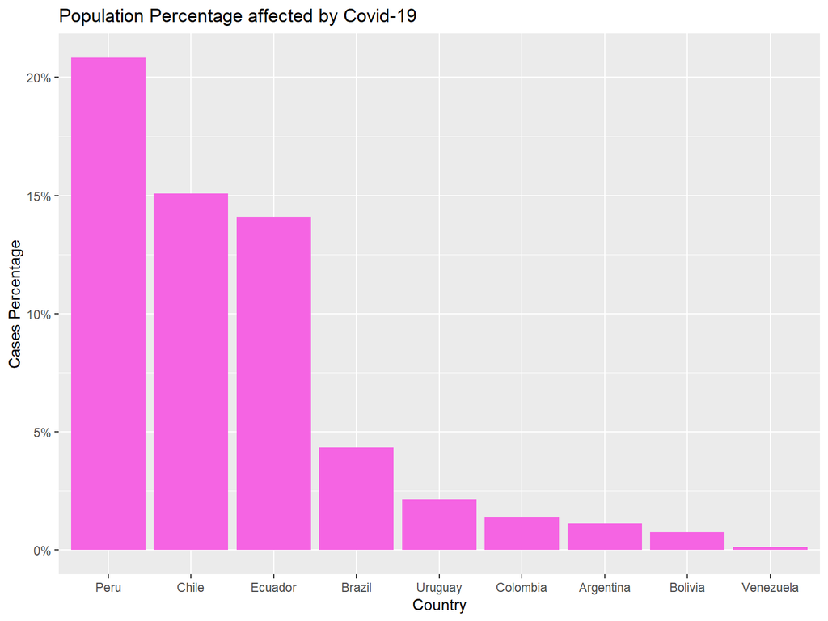